# MasterControl QAL Performance: Exploratory Data Analysis

Understanding the Mx Conversion Gap

Author

Thomas Beck

Published

January 1, 2026

**NoteProject Context**

This document is my individual exploratory analysis for MasterControl’s QAL (Qualified Accepted Lead) pipeline data. The objective is to diagnose why the Mx product line converts leads to SQL at a lower rate than Qx, and to identify which lead segments, title signals, and pipeline behaviors explain the gap. The features engineered here feed directly into the team’s modeling phase.

# Executive Summary

MasterControl’s Mx product converts leads to SQL at approximately 12.7% compared to Qx at approximately 19.7%—a 7 percentage-point gap that represents significant unrealized pipeline value.

**Mx vs Qx Performance Summary**

[output not shown]

# Data Preparation & Feature Engineering

The raw CRM data requires feature engineering to surface useful signals. I built title-parsing logic to extract seniority, functional domain, and scope from free-text contact titles. Record completeness serves as a rough proxy for buyer seriousness—leads with more filled-in fields tend to convert at higher rates.

**Dataset Overview**

| Metric | Value |
| --- | --- |
| Total Records | 16,815 |
| Mx Leads | 4,239 |
| Qx Leads | 12,547 |
| Overall Conversion Rate | 17.9% |
| Mx Conversion Rate | 12.6% |
| Qx Conversion Rate | 19.7% |
| Decision Makers (Director+) | 3,066 (18.2%) |
| Recycled (Near-Miss) | 12,067 |

The pipeline loads the QAL records, standardizes column names, and engineers five feature families from the raw CRM fields. I parsed seniority from free-text titles using regex (C-Suite → SVP → VP → Director → Manager → IC), extracted functional domain (Quality, Regulatory, Mfg/Ops, IT, R&D, PMO), and identified geographic scope keywords (Global, Regional, Site). A binary decision-maker flag and a record completeness score round out the feature set. The target variable `is_success` is defined as any lead reaching SQL, SQO, or Won stage.

# The Conversion Gap

This section establishes the Mx vs Qx performance difference with statistical rigor and visualizes where leads exit the pipeline.

## Mx vs Qx Conversion Comparison

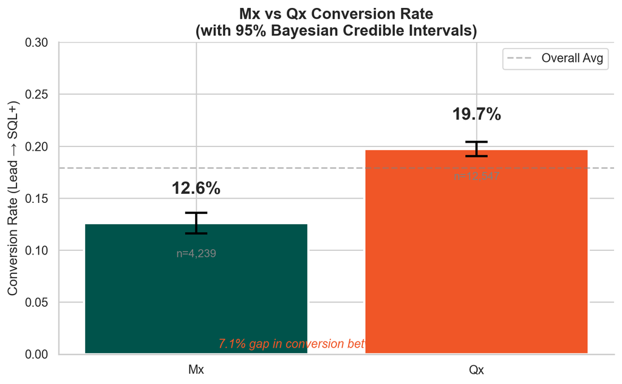

Qx outperforms Mx by approximately 7 percentage points in lead-to-SQL conversion.

The credible intervals confirm this is not a sampling artifact—the gap is statistically meaningful. Mx converts at roughly two-thirds the rate of Qx, and the 95% Bayesian intervals do not overlap. I used a Beta-Binomial conjugate model here instead of frequentist confidence intervals because it handles small sub-segment sample sizes more gracefully, which matters for the interaction analyses later in this report.

## Funnel Drop-Off

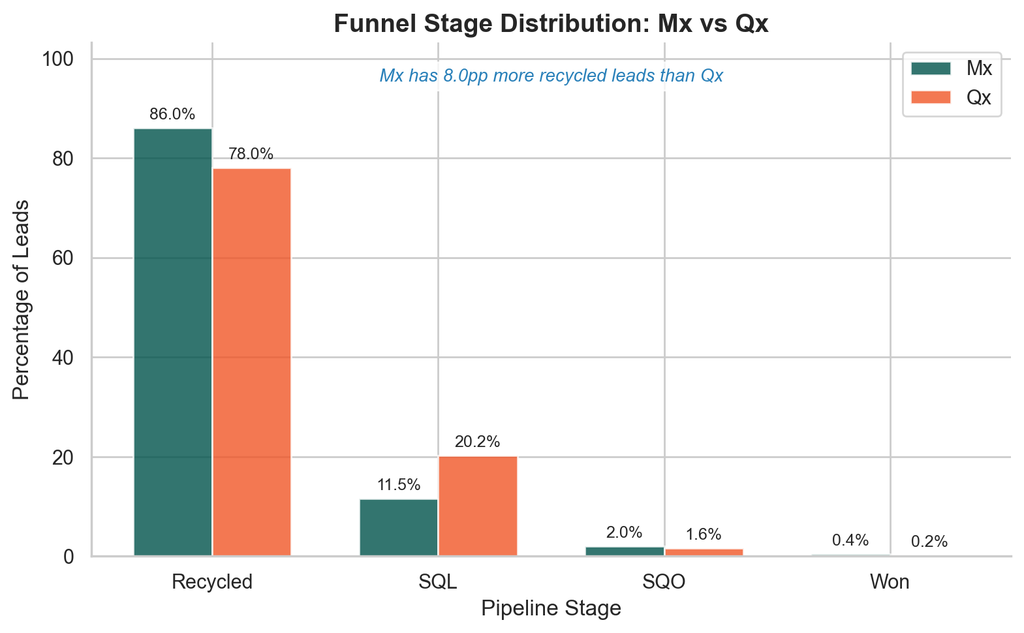

Stage distribution showing where Mx and Qx leads exit the pipeline.

**Funnel Stage Distribution**

| Stage | Mx (%) | Qx (%) |
| --- | --- | --- |
| Recycled | 86 | 78 |
| SQL | 11.5 | 20.2 |
| SQO | 2 | 1.6 |
| Won | 0.4 | 0.2 |

The funnel breakdown reveals where the gap materializes. Mx has a noticeably higher share of recycled leads than Qx, meaning more Mx leads stall in the pipeline rather than converting or being cleanly disqualified. I found this interesting because it suggests these are not bad leads—they were not rejected on quality grounds but simply did not progress. That distinction matters because it frames the recycled population as a recovery opportunity rather than a sunk cost.

# Velocity and Recycled Lead Analysis

If Mx leads take longer to convert, the issue may be sales enablement (training, content, follow-up SLAs) rather than lead targeting. This section also maps the recycled lead population to identify which segments hold the most recovery potential.

## Pipeline Velocity

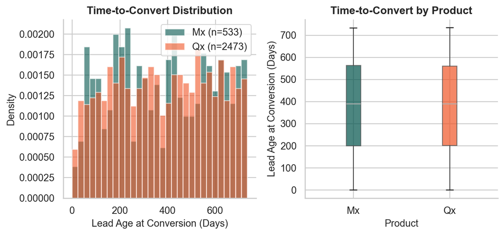

**Pipeline Velocity Statistics**

| Product | Median Days | Mean Days | P25 | P75 | N Converted |
| --- | --- | --- | --- | --- | --- |
| Mx | 389 | 381 | 200 | 564 | 533 |
| Qx | 389 | 382 | 202 | 560 | 2,473 |

## Recycled Lead Heatmap

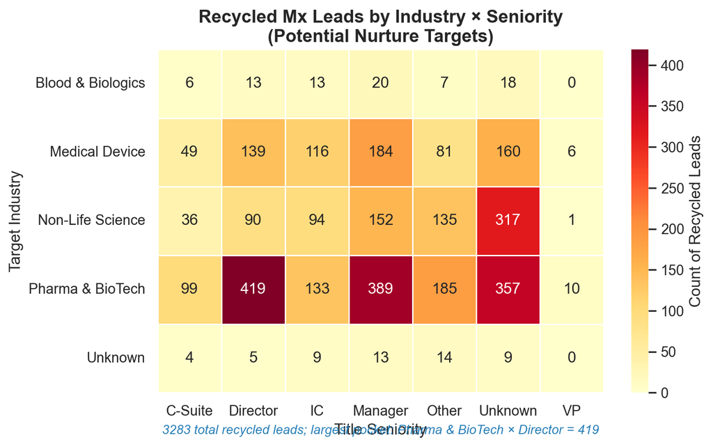

Recycled Mx leads by industry and seniority. These are not lost—they are dormant.

**Recycled Mx Lead Summary**

| Metric | Value |
| --- | --- |
| Total Recycled Mx Leads | 3,287 |
| Decision Maker Rate | 26.8% |
| Top Industry | Pharma & BioTech |
| Top Seniority | Unknown |

The heatmap reveals where the dormant pipeline sits. These recycled leads were not disqualified on quality grounds—they simply stalled. The densest cells indicate which industry-seniority combinations would benefit most from a re-engagement campaign. I think this is the lowest-hanging fruit in the analysis: these contacts already engaged with MasterControl once and may convert with a better-timed or better-positioned follow-up.

# Signal Detection

This section moves beyond univariate bar charts to identify which specific title words, seniority-industry combinations, and scope modifiers predict conversion. My goal here was to find actionable targeting signals that go beyond the broad categories I already engineered.

## Semantic Signal Analysis (Log-Odds)

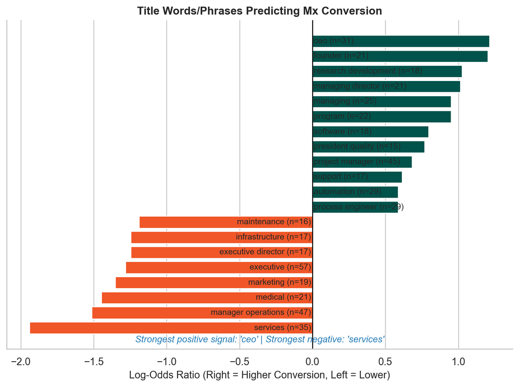

Title words and phrases associated with higher (green) or lower (orange) Mx conversion.

**Top Phrases Predicting Conversion**

| Phrase | Log-Odds | Frequency |
| --- | --- | --- |
| ceo | 1.213 | 31 |
| founder | 1.202 | 21 |
| research development | 1.025 | 18 |
| managing director | 1.015 | 21 |
| managing | 0.951 | 25 |
| program | 0.951 | 22 |
| software | 0.797 | 18 |
| president quality | 0.768 | 15 |

**Phrases Predicting Non-Conversion**

| Phrase | Log-Odds | Frequency |
| --- | --- | --- |
| services | -1.94 | 35 |
| manager operations | -1.513 | 47 |
| medical | -1.447 | 21 |
| marketing | -1.352 | 19 |
| executive | -1.283 | 57 |

The log-odds analysis goes beyond the seniority/function categories I already engineered and surfaces the specific words and bigrams in contact titles that predict Mx conversion. Positive log-odds (green) indicate phrases appearing more often in converted leads; negative (orange) appear more often in non-converted leads. This serves two purposes: it validates my seniority parsing (director-level terms should appear on the right side of the chart), and it surfaces signals the regex categories may have missed entirely—bigrams like “quality director” vs “project coordinator” carry very different conversion profiles that single-word parsing would flatten.

## Seniority × Industry × Model Interaction

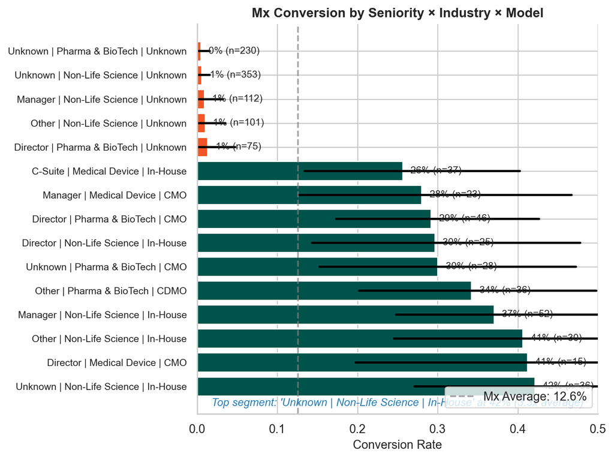

Conversion rates by Seniority × Industry × Manufacturing Model for Mx. Green = above average, orange = below.

**Top 10 Mx Segments by Conversion Rate**

[output not shown]

The three-way interaction reveals the ideal customer profile (ICP) for Mx. Rather than optimizing seniority, industry, or manufacturing model in isolation, this analysis identifies which *combinations* produce outsized conversion rates. I filtered to segments with at least 15 observations to avoid small-sample noise, and used Bayesian credible intervals so the uncertainty is visible. The top-converting segments convert at multiples of the Mx average, which means that targeted outreach to these specific combinations should yield meaningfully better pipeline efficiency than broad-based campaigns.

## Scope Lift Analysis

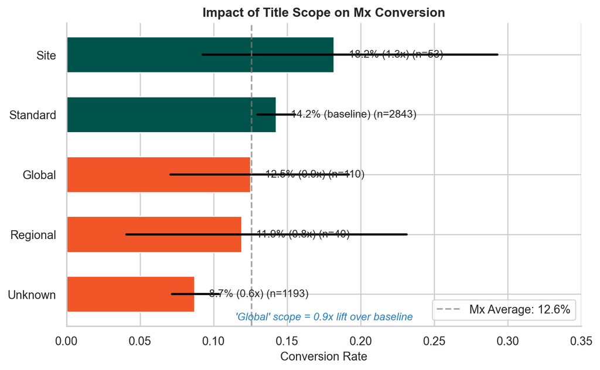

**Scope Lift Analysis (Mx)**

| Scope | N | Rate | Lift |
| --- | --- | --- | --- |
| Unknown | 1193 | 8.7% | 0.6x |
| Regional | 40 | 11.9% | 0.8x |
| Global | 110 | 12.5% | 0.9x |
| Standard | 2843 | 14.2% | baseline |
| Site | 53 | 18.2% | 1.3x |

# Export and Conclusion

## Conclusion

These findings and the engineered features (seniority, function, scope, record completeness) feed directly into the team’s modeling phase, where they serve as candidate predictors for a lead scoring model.

*MasterControl EDA V3 — Thomas Beck, Spring 2026*